# Quiz Socio-Economico

Diego Torres

Marzo de 2020

### **Estudio Socio-Economico**

A continuación se presenta algunas Variables socioeconómicas que caracterizan el grado de desarrollo de algunos paises del mundo:

**X1:** Tasa de mortalidad infantil por cada 100 nacidos vivos  
**X2:** Porcentaje de mujeres en la poblacion activa  
**X3:** Producto Nacional Bruto (PNB) per capita en 1995 (en $)  
**X4:** Produccion de electricidad en millones de kw/h  
**X5:** Promedio lineas telefonicas por cada 1000 habitantes  
**X6:** Consumo de agua per capita en m3 (de 1980 a 1995)  
**X7:** Consumo de energia per capita en 1994  
**X8:** Emision de CO2 per capita en 1992 (en Tm)

```
## 'data.frame':    18 obs. of  9 variables:
##  $ Pais          : Factor w/ 18 levels "Albania","Angola",..: 1 2 3 4 5 6 7 8 9 10 ...
##  $ MortalidadInfa: int  30 124 95 90 112 73 72 45 58 113 ...
##  $ MujeresAct    : int  41 46 48 43 41 51 43 30 46 48 ...
##  $ PNBperC       : int  670 410 370 680 100 390 250 600 280 80 ...
##  $ ProdElectr    : int  3903 955 6 435 1293 6115 362 2672 3539 490 ...
##  $ PromTelef     : int  12 6 5 8 2 4 8 29 9 3 ...
##  $ ConsumoAgua   : int  94 57 26 20 51 35 7 294 87 55 ...
##  $ ConsumoEnergia: int  341 89 20 331 22 93 29 204 110 40 ...
##  $ EmisionesCO2  : num  1.2 0.5 0.1 1.6 0.1 0.2 0.1 0.6 0.2 0.1 ...
## NULL
```

```
##  MortalidadInfa     MujeresAct       PNBperC        ProdElectr
##  Min.   : 30.00   Min.   :28.00   Min.   : 80.0   Min.   :   6
##  1st Qu.: 59.00   1st Qu.:40.25   1st Qu.:252.5   1st Qu.: 934
##  Median : 79.50   Median :43.00   Median :375.0   Median :1510
##  Mean   : 79.67   Mean   :41.67   Mean   :366.1   Mean   :2440
##  3rd Qu.: 98.75   3rd Qu.:46.00   3rd Qu.:507.5   3rd Qu.:3322
##  Max.   :124.00   Max.   :51.00   Max.   :680.0   Max.   :7785
##    PromTelef       ConsumoAgua     ConsumoEnergia   EmisionesCO2
##  Min.   : 2.000   Min.   :  7.00   Min.   : 20.0   Min.   :0.1000
##  1st Qu.: 4.000   1st Qu.: 42.75   1st Qu.: 35.5   1st Qu.:0.1000
##  Median : 8.000   Median : 90.50   Median : 95.0   Median :0.2500
##  Mean   : 9.056   Mean   :154.17   Mean   :144.3   Mean   :0.4889
##  3rd Qu.:11.500   3rd Qu.:198.00   3rd Qu.:205.5   3rd Qu.:0.6000
##  Max.   :29.000   Max.   :633.00   Max.   :438.0   Max.   :1.8000
```

Realice un analisis de componentes principales, ¿Que podemos decir de las variables socioeconomicas?, ¿Qué podemos afirmar de los paises?.

Al ser ser un analisis de componentes principales, se requiere que la base de datos utilizada dentro de las funciones de PCA sea completamente numérica, de lo contrario, se obtendrán errores que impediran el analisis. La información completa del análisis será obtenido por el output de la función PCA() de la libreria FactoMineR.

```r
library("FactoMineR")
library("factoextra")

se.pca <- PCA(socioEcon, graph = FALSE)
print(se.pca)
```

```
## **Results for the Principal Component Analysis (PCA)**
## The analysis was performed on 18 individuals, described by 8 variables
## *The results are available in the following objects:
##
##    name               description
## 1  "$eig"             "eigenvalues"
## 2  "$var"             "results for the variables"
## 3  "$var$coord"       "coord. for the variables"
## 4  "$var$cor"         "correlations variables - dimensions"
## 5  "$var$cos2"        "cos2 for the variables"
## 6  "$var$contrib"     "contributions of the variables"
## 7  "$ind"             "results for the individuals"
## 8  "$ind$coord"       "coord. for the individuals"
## 9  "$ind$cos2"        "cos2 for the individuals"
## 10 "$ind$contrib"     "contributions of the individuals"
## 11 "$call"            "summary statistics"
## 12 "$call$centre"     "mean of the variables"
## 13 "$call$ecart.type" "standard error of the variables"
## 14 "$call$row.w"      "weights for the individuals"
## 15 "$call$col.w"      "weights for the variables"
```

El resultado es una lista con multiple información del analisis, procederemos a conocer mas sobre los nuevos ejes generados en el analisis de PCA, por ejemplo, los valores propios de cada eje y el porcentaje de variabilidad total que cada eje tiene asociado.

```r
## descripción de los nuevos ejes
print(se.pca$eig)
```

```
##        eigenvalue percentage of variance cumulative percentage of variance
## comp 1 3.75396969             46.9246212                          46.92462
## comp 2 1.92856531             24.1070664                          71.03169
## comp 3 0.83589467             10.4486834                          81.48037
## comp 4 0.72301070              9.0376338                          90.51800
## comp 5 0.34051808              4.2564760                          94.77448
## comp 6 0.30503439              3.8129299                          98.58741
## comp 7 0.09905110              1.2381388                          99.82555
## comp 8 0.01395606              0.1744507                         100.00000
```

Para ver esta informacion un poco mas grafica, se utiliza la siguiente funcion

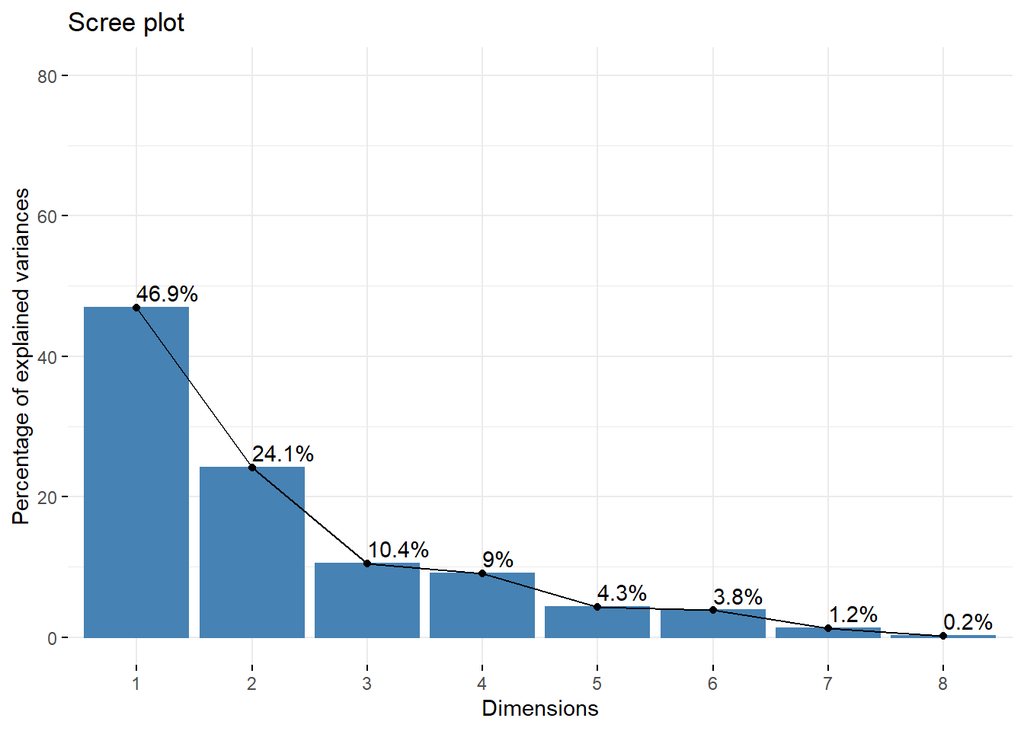

```r
fviz_eig(se.pca, addlabels = TRUE, ylim=c(0,80))
```

El grafico anterior nos muestra que el 71,03% de informacion dada por las variables originales se encuentra en los dos primeros ejes. Ahora, veremos como esta informacion de las variables ha sido repartida en los diferentes nuevos ejes principales, las veremos mas en detalle a continuacion

```r
var. <- se.pca$var
```

Una de las variables resultantes mas importantes del analisis es la contribucion o el aporte de las variables originales en la creacion de los nuevos ejes. Un grafico de correlacion ilustrara muy bien esta informacion

```r
#CONTRIBUCIÓN DE LAS VARIABLES EN LOS NUEVOS EJES

library("corrplot")
head(var.$contrib)
```

```
##                    Dim.1      Dim.2      Dim.3     Dim.4      Dim.5
## MortalidadInfa 13.943122  0.2159015  0.1052044 49.719624 17.6707471
## MujeresAct      4.947102 37.3828678  0.2057235  5.761781  0.2379013
## PNBperC        17.124793  3.9937475  7.3133103  0.062283 13.2935391
## ProdElectr      4.623047  8.2054693 77.9432761  0.151767  0.7077408
## PromTelef      16.869020  3.3714882  0.8323463 12.000654 56.9086398
## ConsumoAgua     3.132585 36.6412700  8.9616224  4.253464 10.2103889
```

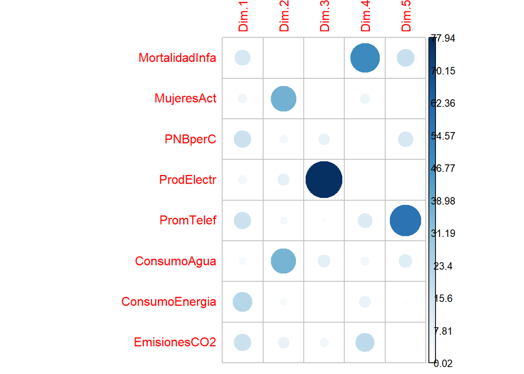

```r
corrplot(var.$contrib, is.corr = FALSE)
```

Lo mas importante que nos dice este tipo de graficas es que cada variable parece mostrar una fuerte relacion con cierto eje en especifico. Por ejemplo, en el primer eje, cinco variables parecen contribuir de manera equitativa con informacion, mientras que en el eje dos, las demas variables son las que hacen presencia mas fuertemente, aportando así la mayor cantidad posible de informacion posible dentro de los primeros dos ejes.

Ahora, el siguiente grafico nos mostrara la contribucion total de las variables en los dos principales ejes

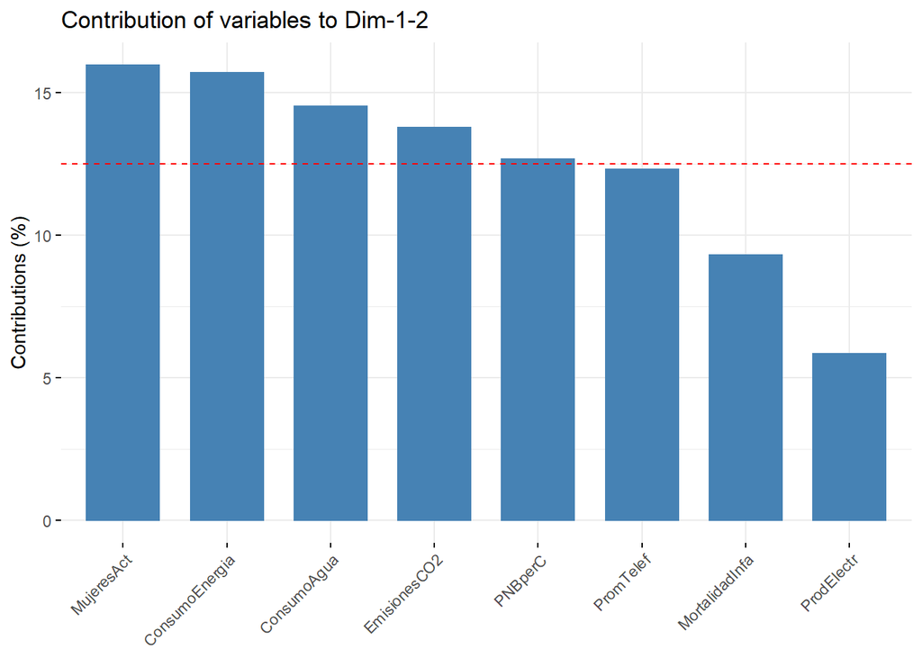

```r
## grafico de barras que muestra la contribucion de la variables en dim1 y dim2
fviz_contrib(se.pca, choice="var", axes=1:2, top=10)
```

La grafica nos indica que son cinco las variables que aportan mayor informacion en la generacion de los ejes 1 y 2.

Ahora, observaremos otra de las variables del analisis de PCA: la calidad de representacion, es decir, la correlacion de las variables con los nuevos ejes principales. De igual manera, se presentara esta informacion de manera grafica.

```r
#CORRELACIÓN ENTRE LAS VARIABLES Y LOS NUEVOS EJES
# (CALIDAD DE LA REPRESENTACIÓN)
head(var.$cos2)
```

```
##                    Dim.1       Dim.2        Dim.3        Dim.4
## MortalidadInfa 0.5234206 0.004163801 0.0008793979 0.3594782050
## MujeresAct     0.1857127 0.720953019 0.0017196320 0.0416582959
## PNBperC        0.6428595 0.077022028 0.0611315710 0.0004503127
## ProdElectr     0.1735478 0.158247834 0.6515236919 0.0010972920
## PromTelef      0.6332579 0.065021351 0.0069575384 0.0867660118
## ConsumoAgua    0.1175963 0.706650823 0.0749097244 0.0307530025
##                       Dim.5
## MortalidadInfa 0.0601720883
## MujeresAct     0.0008100969
## PNBperC        0.0452669036
## ProdElectr     0.0024099854
## PromTelef      0.1937842057
## ConsumoAgua    0.0347682198
```

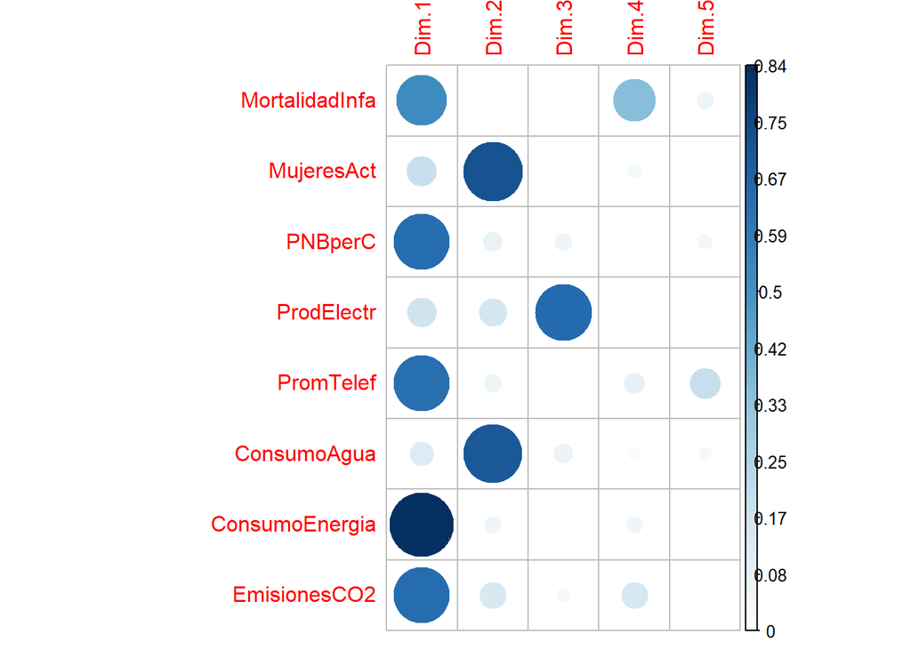

```r
corrplot(var.$cos2, is.corr = FALSE)
```

El grafico muestra similitudes importantes con el de contribución, las variables, en este caso, que aportaron mayor informacion en el primer eje, vienen siendo más correlacionados a este mismo eje, igual para el segundo.  
Igualmente, veremos las variables que estan mas correlacionadas con los principales nuevos ejes mediante el siguiente codigo

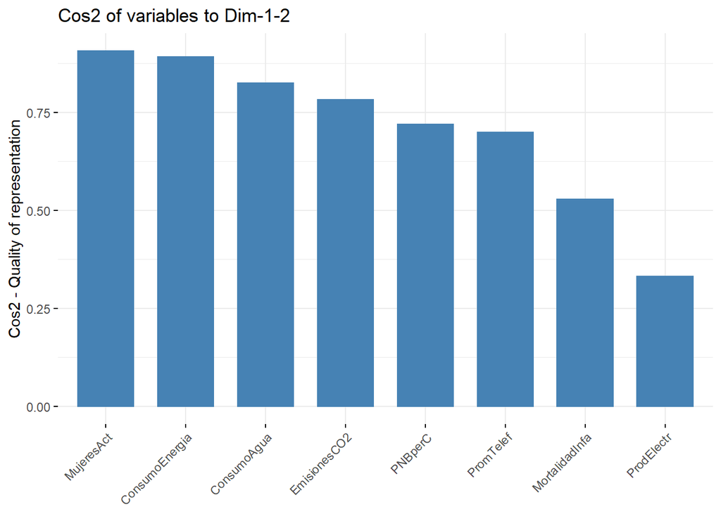

```r
fviz_cos2(se.pca, choice="var", axes=1:2, TOP=10)
```

Este grafico es muy interesante ya que muestra que al menos 6 de las 8 variables originales están altamente correlacionadas (>70%) con los dos ejes principales.

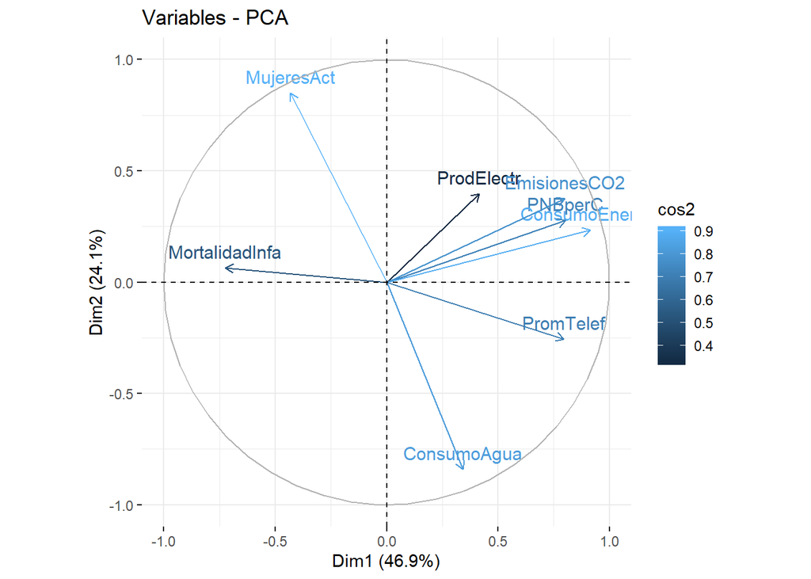

```r
# Grafica de correlación circular
fviz_pca_var(se.pca, col.var="cos2")
```

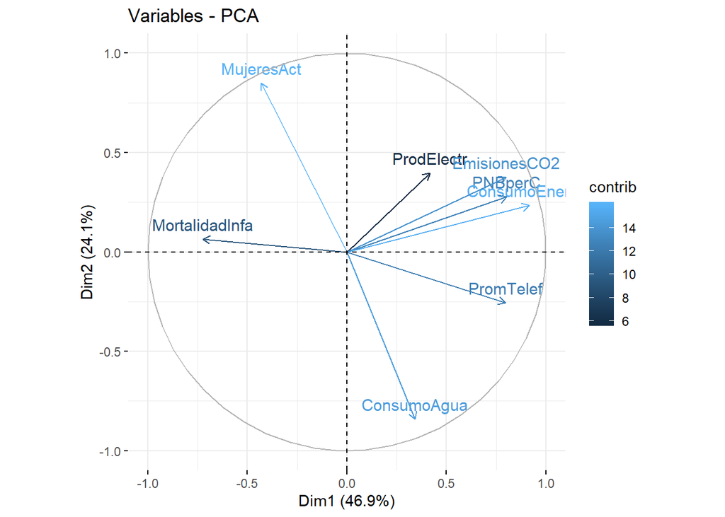

```r
fviz_pca_var(se.pca, col.var="contrib")
```

```r
# o plot.PCA(se.pca, choix="var")
```

Sin duda, el grafico mas importante del analisis, en este se ven las relaciones entre variables y los nuevos ejes, la contribucion de las variables en el modelo, etc. Entre las cosas que se pueden observar son correlaciones sin causalidad, tales como la que existe entre el consumo de agua y el porcentaje de mujeres activas por pais, la cual muestra una correlacion negativa. También, se observa que variables como la produccion de electricidad es una variable poco correlacionada y de poco aporte a la generacion de los componentes principales. Además, la mayoria de variables están más relacionadas con el eje 1 y variables como el consumo de agua y porcentaje de mujeres activas con el eje 2.\

Finalmente, aqui termina el analisis por variables, ahora iniciaremos el analisis por individuos u observaciones. De igual manera, los individuos tienen contribucion y correlacion con los nuevos ejes, así que será un procedimiento similar

```r
#distancia de los individuos al centro de la nube
se.pca$ind$dist
```

```
##        1        2        3        4        5        6        7        8
## 3.374463 2.133711 2.207913 3.371236 2.610040 2.471911 1.898056 3.959947
##        9       10       11       12       13       14       15       16
## 1.457102 2.833125 1.849245 3.143612 1.648167 3.951830 2.374557 2.541593
##       17       18
## 2.651242 4.324493
```

```r
#contribucion de los individuos en la construcion de los primeros tres ejes
se.pca$ind$contrib[,1:3]
```

```
##          Dim.1        Dim.2        Dim.3
## 1  12.96516190  3.784054002  0.601993556
## 2   2.52730431  1.515986792  4.199855767
## 3   4.82613616  0.840000377  5.601241660
## 4   4.26669112  7.426619066 25.143750954
## 5   8.81975936  0.138054376  0.002304789
## 6   0.67846798  8.242195324 12.991973566
## 7   2.71478612  0.004649115  3.159502887
## 8  13.98814308  9.064809879  0.763481072
## 9   0.19392436  0.615746793  2.369536206
## 10 10.61007665  0.238440208  0.432591846
## 11  4.10784534  1.445602697  0.101744474
## 12  8.27520033  7.119268510  0.141439495
## 13  0.35966513  0.170341837  3.657473956
## 14  0.10789644 35.064957302  4.252546912
## 15  6.42934779  1.008480758  0.395927161
## 16  0.61303807  9.868461317  0.139981416
## 17  0.02247121  2.161488299 29.766537747
## 18 18.49408465 11.290843347  6.278116537
```

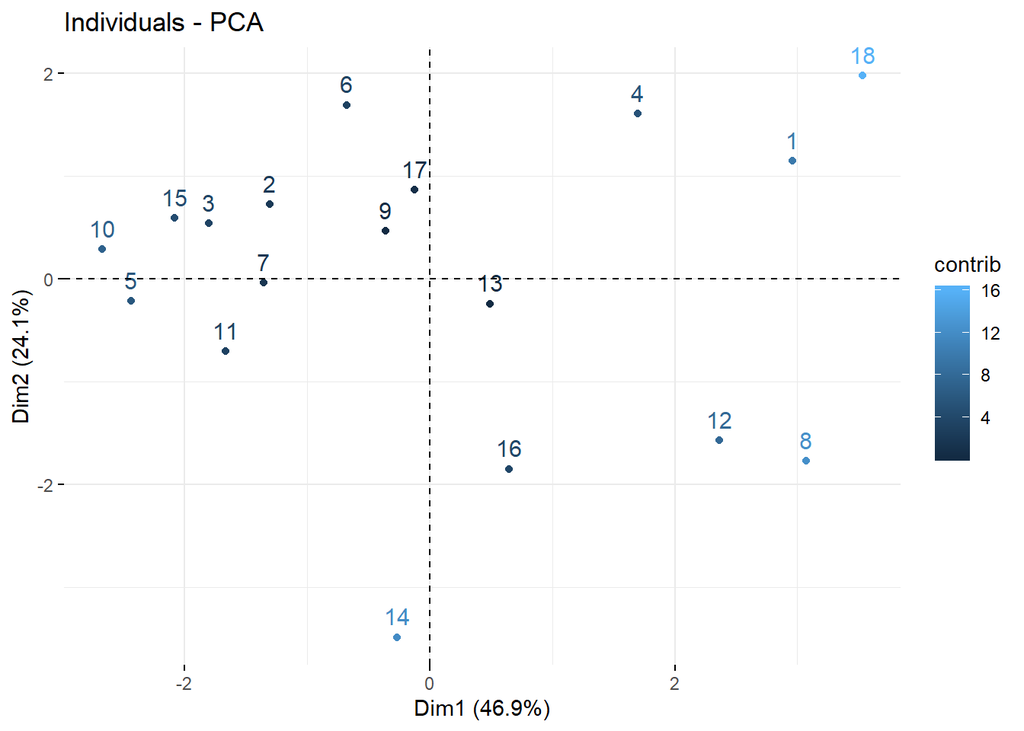

```r
#Contribucion
fviz_pca_ind(se.pca, col.ind = "contrib")
```

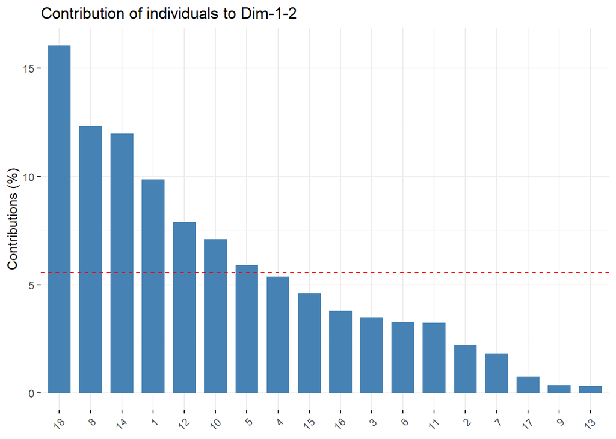

```r
fviz_contrib(se.pca, choice = "ind", axes=1:2)
```

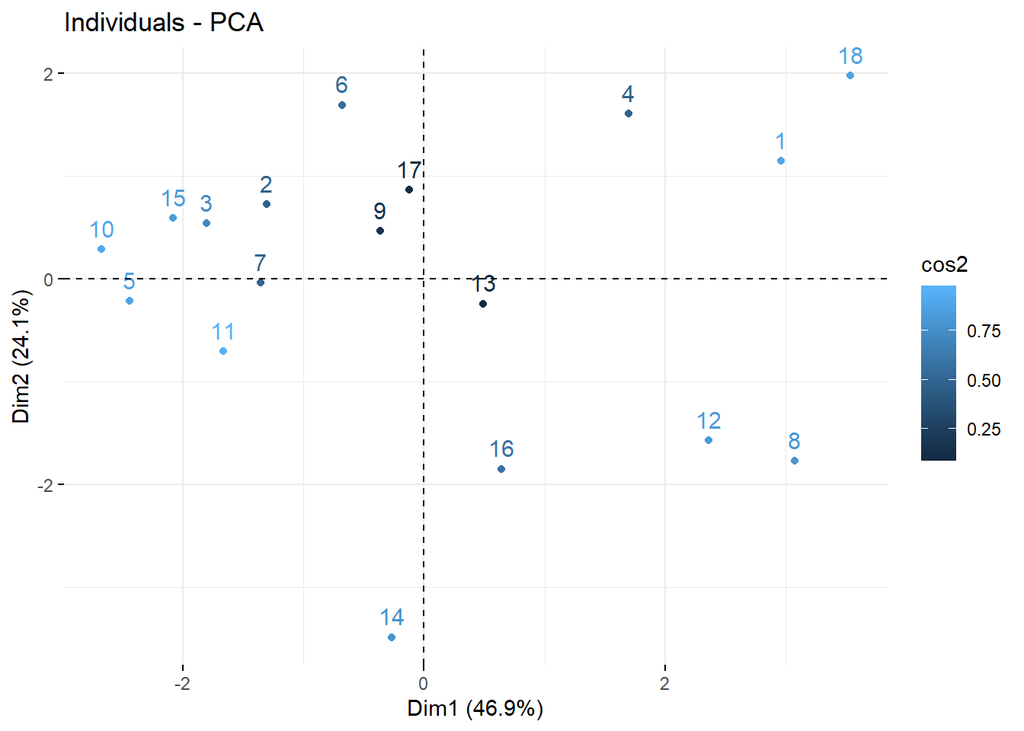

```r
# Calidad de representacion
fviz_pca_ind(se.pca, col.ind = "cos2")
```

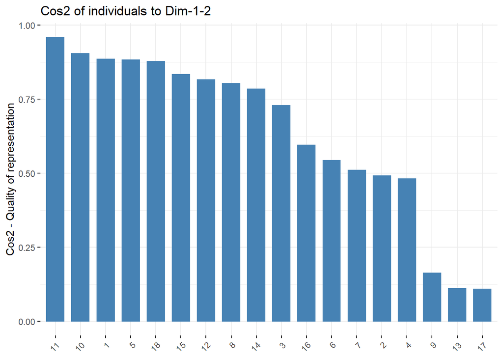

```r
fviz_cos2(se.pca, choice = "ind", axes=1:2)
```

Ambas graficas de correlacion circular resultantes en este analisis son ligeramente distintas en cuanto a la clasificacion por color, debido a que los individios presentan contribuciones bajas en los ejes, pero son altamente relacionados a estos, efecto que se puede observar mejor en la gráfica de visualizacion de la calidad de representacion en ambos ejes principales (grafico de barras).

Como conclusiones finales podemos decir que el analisis de PCA agrupa un buen porcentaje de informacion del total que contenia la base de datos. Por un lado, variables como la produccion de electricidad no afectaron significativamente en el resultado, ya que presentaban baja contribucion y baja correlacion con los ejes principales generados. Mientras que por el lado de las observaciones, se observó una tendencia en los paises que presentaban las mismas caracteristicas de la variable anteriormente nombrada, y es que los 3 paises son africanos (Kenia, Senagal y Zambia), paises con una clara problemática social.